# BL40A2010 Introduction to IoT-Based Systems

## Assignment 4, 18.01.2024

### Author: Jesse Peltola

**(1) Draw a graph with star topology with five nodes (one in the center $A$, four in the edges $B$-$E$). If the topology is directed as a many-to-one topology, write the structure of awareness of the system, considering that nodes $B$-$E$ acquire and process data about a supporting reality $T$, while $A$ can only receive data from it. Remember the notation $Xy$ means the image of $X$ by $Y$.**

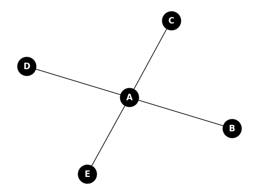

```python
import networkx as nx #https://networkx.github.io/
import matplotlib.pyplot as plt #https://matplotlib.org/
import pandas as pd
import scipy as sp
import numpy as np

G = nx.Graph()
G.add_node("A")
G.add_nodes_from(["B", "C", "D", "E"])
G.add_edges_from([("A", "B"), ("A", "C"), ("A", "D"), ("A", "E")])
nx.draw_networkx(G, node_color='black', font_color='white', edge_color='black', font_weight='bold',  node_size=700)
plt.axis('off')
plt.show()
```

According to the lecture notes, the reflexive system $\Omega = A + Ab + Ac + Ad + Ae = A (1 + b + c + d + e)$

So the structure of awareness is $\omega = (1 + b + c + d + e)$

**(2) Assume that graph illustrate a scenario of four sensor nodes that also (pre-)process data and one aggregator node as follows. Nodes $B$ and $C$ monitor temperature and wind speed at Airport station in Lappeenranta, respectively. Nodes $D$ and $E$ monitor temperature and wind speed at Lepola station in Lappeenranta, respectively. Nodes $B$ and $D$ send a binary message to $A$ indicating if during that period the temperature was more than $25$ degrees ("1" means above, "0" means below or equal to). Likewise nodes $C$ and $E$ send a binary message to $A$ indicating if during that period the wind speed was more than $5$ m/s ("1" means above, "0" means below or equal to). Download and plot the data from [FMI](http://en.ilmatieteenlaitos.fi/download-observations#!/) with 1 hour resolution during July, 2018. Using this data, plot the binary signals sent from the nodes $B$-$E$ to the aggregator $A$.**

```python
lepola_data = pd.read_csv("lappeenranta_lepola_2018.csv", dayfirst=True, sep=",",
                          header = 0, decimal=b".", usecols=[0, 1, 2, 3, 4, 5])
lappeenranta_airport_data = pd.read_csv("lappeenranta_airport_2018.csv", dayfirst=True, sep=",",
                          header = 0, decimal=b".", usecols=[0, 1, 2, 3, 4, 5])

#In some reason, pd.read_csv did not convert parse_dates to dates so it is needed to do manually
lepola_data["Date"] = pd.to_datetime(lepola_data[['Year', 'Month', 'Day', 'Time [UTC]']].astype(str).agg('-'.join, axis=1), format='%Y-%m-%d-%H:%M')
lappeenranta_airport_data["Date"] = pd.to_datetime(lappeenranta_airport_data[['Year', 'Month', 'Day', 'Time [UTC]']].astype(str).agg('-'.join, axis=1), format='%Y-%m-%d-%H:%M')

# Dropping the unnecessary columns
lepola_data.drop(['Year', 'Month', 'Day', 'Time [UTC]'], axis=1, inplace=True)
lappeenranta_airport_data.drop(['Year', 'Month', 'Day', 'Time [UTC]'], axis=1, inplace=True)
# TemperaturesData.drop(['Year', 'Month', 'Day', 'Time'], axis = 1, inplace = True)
lepola_data.set_index("Date", inplace=True)
lappeenranta_airport_data.set_index("Date", inplace=True)

#Converting lepola wind speed from object to float
lepola_data["Wind speed mean [m/s]"] = pd.to_numeric(lepola_data["Wind speed mean [m/s]"], errors="coerce")

#Creating Nodes
Node_B = lappeenranta_airport_data["Air temperature mean [°C]"]
Node_C = lappeenranta_airport_data["Wind speed mean [m/s]"]
Node_D = lepola_data["Air temperature mean [°C]"]
Node_E = lepola_data["Wind speed mean [m/s]"]
```

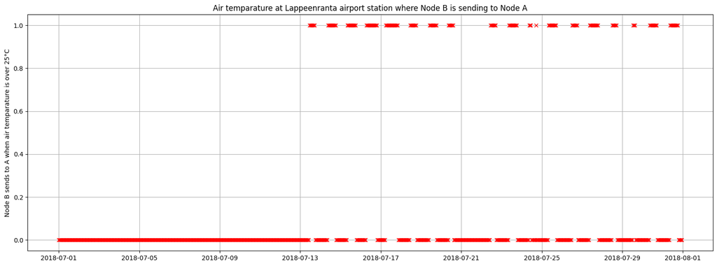

```python
plt.figure(figsize=(16, 6))
plt.plot(Node_B["2018-07-01":"2018-07-31"] > 25, color="red", marker="x", linestyle='', label="Air temperature")
plt.title("Air temparature at Lappeenranta airport station where Node B is sending to Node A")
plt.ylabel("Node B sends to A when air temparature is over 25°C")
plt.grid(True)
plt.tight_layout()
plt.show()
```

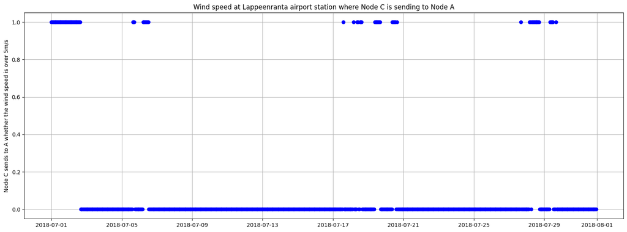

```python
plt.figure(figsize=(16, 6))
plt.plot(Node_C["2018-07-01":"2018-07-31"]>5, color="blue", linestyle="", marker="o", label="Wind speed")
plt.title("Wind speed at Lappeenranta airport station where Node C is sending to Node A")
plt.ylabel("Node C sends to A whether the wind speed is over 5m/s")
plt.tight_layout()
plt.grid(True)
plt.show()
```

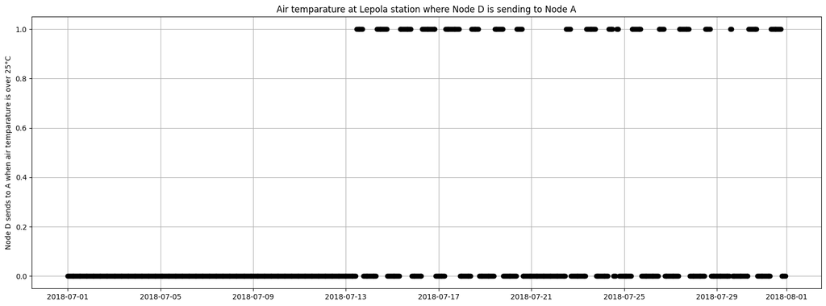

```python
plt.figure(figsize=(16, 6))
plt.plot(Node_D["2018-07-01":"2018-07-31"] > 25, color="black", marker="o", linestyle='', label="Air temperature")
plt.title("Air temparature at Lepola station where Node D is sending to Node A")
plt.ylabel("Node D sends to A when air temparature is over 25°C")
plt.grid(True)
plt.tight_layout()
plt.show()
```

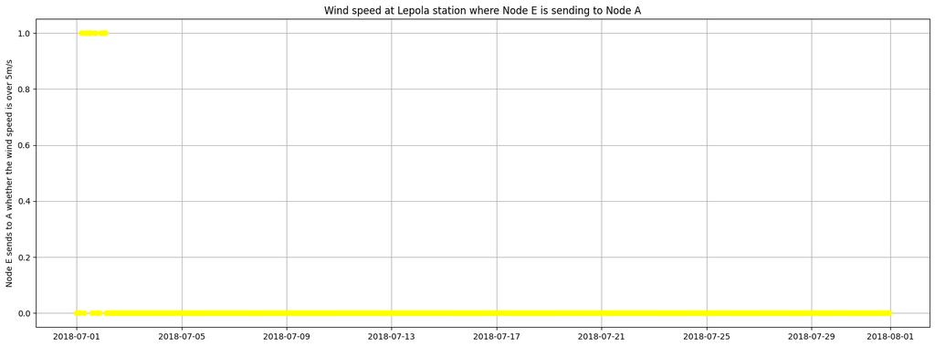

```python
plt.figure(figsize=(16, 6))
plt.plot(Node_E["2018-07-01":"2018-07-31"]>5, color="yellow", linestyle="", marker="o", label="Wind speed")
plt.title("Wind speed at Lepola station where Node E is sending to Node A")
plt.ylabel("Node E sends to A whether the wind speed is over 5m/s")
plt.tight_layout()
plt.grid(True)
plt.show()
```

**(3) Node $A$ needs to identify risky situations in Lappeenranta when the temperature is above $25$ degrees and the wind is above $5$ m/s based on the sensors' signals. If a risky situation is identified at node $A$ as binary number "1" while normal situations as "0". How would you solve this problem? Plot the output signal from node $A$ and discuss its relation to the input signals from $B$-$E$.**

[figure not shown]

```python
#Numpy offer logical operators so this is simplier
condition = (Node_B > 25) | (Node_D > 25) #Finding the temperature over 25
condition &= (Node_C > 5) | (Node_E > 25) #Finding the wind speed over 5
node_A = condition.astype(int)

fig, ax = plt.subplots(figsize=(16,6))
plt.plot(Node_B.index[node_A == 1], node_A[node_A == 1], label="Risky weather", color="red", marker='x', linestyle='')
plt.plot(Node_B.index[node_A == 0], node_A[node_A == 0], label="Normal weather", color="blue", marker='o', linestyle='')
plt.legend()
plt.grid(True)
plt.tight_layout()
plt.title("Finding the risky weather at Lappeenranta, over 25°C and over 5m/s")
plt.ylabel("Risky situation identified as 1 at node A")
plt.show()
```